[figure not shown]

VDC-17

ABS Sequence Control

VEHICLE DYNAMICS CONTROL (VDC)

5. ABS Sequence Control

A: OPERATION

1) While the ABS sequence control is being performed, the operation of the hydraulic unit can be checked us-

ing the brake tester or pressure gauge after the hydraulic unit solenoid valve operation.

2) ABS sequence control can be started by the Subaru Select Monitor.

1. ABS SEQUENCE CONTROL WITH SUBARU SELECT MONITOR

NOTE:

In the event of any trouble, the ABS sequence control will not operate.

1) Connect the Subaru Select Monitor to data link connector.

(1) Run the “PC application for Subaru Select Monitor”.

(2) On «Main Menu» display, select {Each System Check}.

(3) Select {Brake Control System}. When {VDC} is displayed, select the [OK] button.

(4) Select the {Function Check Sequence} from {Work Support}, and select {ABS Sequence Control

Mode} when it appears.

2) Follow the procedures displayed in the Subaru Select Monitor to execute the following.

(1) When using a brake tester, depress the brake pedal with a force of 100 N (10.2 kgf, 22.5 lbf).

(2) When using a pressure gauge, press the brake pedal so that the pressure gauge indicates 3,500 kPa

3) The brake system being operated is displayed on the Subaru Select Monitor.

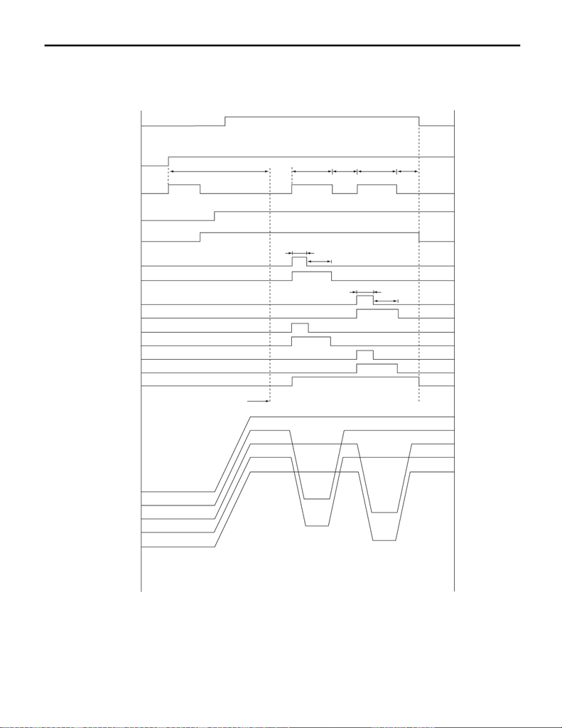

VDC-18

ABS Sequence Control

VEHICLE DYNAMICS CONTROL (VDC)

2. CONDITIONS FOR ABS SEQUENCE CONTROL

NOTE:

The control operation starts at point A.

VDC01320

(1)

(2)

(3)

(4)

(5)

(6)

(7)

(8)

(9)

(10)

(11)

(12)

(13)

(14)

(23)

(24)

(27)

(26)

(25)

V max < 4 km/h (2.5 MPH)

OFF

(16)

(17)

OFF

ON

OFF

ON

OFF

ON

(21)

(18)

OFF

ON

OFF

ON

OFF ON

OFF ON

OFF

ON

OFF

ON

OFF

ON

OFF

ON

ON

(15) (19) (18) (19)

V max < 10 km/h (6 MPH)

(16)

(17)

(17)

(16) (16)

(21)

(18)

(22)

(20)

[figure not shown]

VDC-19

ABS Sequence Control

VEHICLE DYNAMICS CONTROL (VDC)

B: SPECIFICATION

1. CONDITIONS FOR COMPLETION OF ABS SEQUENCE CONTROL

When the following conditions develop, the ABS sequence control stops and ABS operation is returned to the

normal control mode.

• When the speed of at least one wheel reaches 10 km/h (6 MPH).

• When the brake pedal is released during ABS sequence control and the switch - stop light becomes OFF.

• After completion of ABS sequence control.

• When a malfunction is detected.

(1) All wheel speed (11) Rear RH compression valve (20) 0.6 seconds

(2) Ignition key (12) Rear LH decompression valve (21) 0.4 seconds

(3) ABS warning light (13) Rear LH compression valve (22) Point A

(4) Switch - stop light (14) Pump motor (23) Master cylinder pressure

(5) Valve relay (15) A few seconds (24) Front LH wheel cylinder pressure

(6) Front LH decompression valve (16) Light OFF (25) Front RH wheel cylinder pressure

(7) Front LH compression valve (17) Light ON (26) Rear RH wheel cylinder pressure

(8) Front RH decompression valve (18) 1.0 second (27) Rear LH wheel cylinder pressure

(9) Front RH compression valve (19) 1.4 seconds

(10) Rear RH decompression valve